# Звонки в коллцентр

Выполнил: Добрыгин Владимир

Загрузка импортов и файлов

```python
%load_ext autoreload
%autoreload 2
```

```python
import numpy as np
import pandas as pd
import lightgbm as lgb
import catboost as cb
from sklearn.model_selection import train_test_split
from sklearn.metrics import roc_auc_score
from scipy import stats
import faiss
```

```python
data = pd.read_csv('train.csv', sep=',')
test = pd.read_csv('test.csv', sep=',')
webstat = pd.read_csv('t1_webstat.csv', sep=',')
```

# Исследование данных

В этом блоке я постарался перед тем как приступить к задаче, посмотреть и исследовать признаки, подобно тому, как мы делали это в задаче по курильщикам. Кластеризация будет в отдельном блоке

```python
# Посмотрим как выглядит наша таблица
data.head()
```

|  | order_id | create_time | good_id | price | utm_medium | utm_source | sessionkey_id | category_id | parent_id | root_id | model_id | is_moderated | rating_value | rating_count | description_length | goods_qty | pics_qty | model_create_time | is_callcenter |
| --- | --- | --- | --- | --- | --- | --- | --- | --- | --- | --- | --- | --- | --- | --- | --- | --- | --- | --- | --- |
| 0 | 1269921 | 1975-12-26 09:30:08 | 9896348 | 753 | 5 | 8.0 | 123777004 | 139 | 133 | 124 | 123517 | 1 | 5.0 | 6.0 | 1204 | 6 | 2 | 1971-04-14 00:15:20.000 | 1 |
| 1 | 1270034 | 1975-12-26 10:28:57 | 9896348 | 753 | 1 | 2.0 | 123781654 | 139 | 133 | 124 | 123517 | 1 | 5.0 | 6.0 | 1204 | 6 | 2 | 1971-04-14 00:15:20.000 | 0 |
| 2 | 1268272 | 1975-12-25 11:24:28 | 9896348 | 753 | 2 | 3.0 | 123591002 | 139 | 133 | 124 | 123517 | 1 | 5.0 | 6.0 | 1204 | 6 | 2 | 1971-04-14 00:15:20.000 | 1 |
| 3 | 1270544 | 1975-12-26 14:16:06 | 9896348 | 753 | 1 | 1.0 | 123832302 | 139 | 133 | 124 | 123517 | 1 | 5.0 | 6.0 | 1204 | 6 | 2 | 1971-04-14 00:15:20.000 | 1 |
| 4 | 1270970 | 1975-12-26 18:21:47 | 9896348 | 753 | 3 | 56.0 | 123881603 | 139 | 133 | 124 | 123517 | 1 | 5.0 | 6.0 | 1204 | 6 | 2 | 1971-04-14 00:15:20.000 | 0 |

```python
data.info()
```

```
<class 'pandas.core.frame.DataFrame'>
RangeIndex: 104595 entries, 0 to 104594
Data columns (total 19 columns):
 #   Column              Non-Null Count   Dtype
---  ------              --------------   -----
 0   order_id            104595 non-null  int64
 1   create_time         104595 non-null  object
 2   good_id             104595 non-null  int64
 3   price               104595 non-null  int64
 4   utm_medium          104595 non-null  int64
 5   utm_source          94145 non-null   float64
 6   sessionkey_id       104595 non-null  int64
 7   category_id         104595 non-null  int64
 8   parent_id           104595 non-null  int64
 9   root_id             104595 non-null  int64
 10  model_id            104595 non-null  int64
 11  is_moderated        104595 non-null  int64
 12  rating_value        33741 non-null   float64
 13  rating_count        51613 non-null   float64
 14  description_length  104595 non-null  int64
 15  goods_qty           104595 non-null  int64
 16  pics_qty            104595 non-null  int64
 17  model_create_time   103532 non-null  object
 18  is_callcenter       104595 non-null  int64
dtypes: float64(3), int64(14), object(2)
memory usage: 15.2+ MB
```

```python
from analisis_utils import *
get_df_info(data)
```

|  | dtype | vc_max_el | vc_max_freq | nunique | nan | zero | empty_str | trash_score |
| --- | --- | --- | --- | --- | --- | --- | --- | --- |
| is_moderated | int64 | 1 | 0.951 | 2 | -1 | 0.049 | -1 | 0.951 |
| rating_value | float64 | 5.0 | 0.672 | 11 | 0.677 | -1 | -1 | 0.677 |
| is_callcenter | int64 | 0 | 0.645 | 2 | -1 | 0.645 | -1 | 0.645 |
| rating_count | float64 | 1.0 | 0.285 | 30 | 0.507 | 0.136 | -1 | 0.643 |
| description_length | int64 | 0 | 0.384 | 3106 | -1 | 0.384 | -1 | 0.384 |
| utm_source | float64 | 1.0 | 0.476 | 289 | 0.1 | -1 | -1 | 0.1 |
| model_create_time | object | 1975-02-10 17:16:18.000 | 0.005 | 31697 | 0.01 | -1 | -1 | 0.01 |
| pics_qty | int64 | 1 | 0.366 | 34 | -1 | 0.005 | -1 | 0.005 |
| model_id | int64 | 18340251 | 0.005 | 37299 | -1 | -1 | -1 | -1 |
| goods_qty | int64 | 1 | 0.319 | 114 | -1 | -1 | -1 | -1 |
| order_id | int64 | 0.0 | 0.000 | 104595 | -1 | -1 | -1 | -1 |
| create_time | object | 1975-11-27 09:52:30 | 0.000 | 102998 | -1 | -1 | -1 | -1 |
| parent_id | int64 | 154 | 0.094 | 368 | -1 | -1 | -1 | -1 |
| category_id | int64 | 155 | 0.090 | 1733 | -1 | -1 | -1 | -1 |
| sessionkey_id | int64 | 125996889 | 0.000 | 96803 | -1 | -1 | -1 | -1 |
| utm_medium | int64 | 1 | 0.457 | 8 | -1 | -1 | -1 | -1 |
| price | int64 | 264 | 0.009 | 6362 | -1 | -1 | -1 | -1 |
| good_id | int64 | 66921494 | 0.002 | 53691 | -1 | -1 | -1 | -1 |
| root_id | int64 | 1183 | 0.264 | 26 | -1 | -1 | -1 | -1 |

```python
data['utm_source'].unique()
```

```
array([  8.,   2.,   3.,   1.,  56.,  30.,  nan,  45.,   7.,  15.,  29.,
         4.,  40.,  31.,  23.,  14.,  25.,  13.,  34.,  17.,  27.,  12.,
        43.,  46.,  47.,  88.,   5.,  11.,  41.,  28.,  50.,  37.,  10.,
       325.,  60.,  74.,  20.,  18.,  42.,  36.,  24., 238.,  52.,  65.,
        32.,  35.,   6.,  49.,  19.,  48.,   9., 171.,  51.,  59.,  90.,
       106.,  38., 126.,  22., 176.,  77., 117.,  71., 149., 392.,  84.,
       141., 540.,  98., 109.,  61., 225.,  54.,  26.,  53.,  57., 113.,
        16.,  55., 279.,  58., 504., 512.,  97.,  44., 544., 158.,  91.,
       119.,  85.,  33.,  80.,  75.,  66.,  73.,  78., 130., 418., 133.,
        72., 209.,  21., 137.,  92., 295.,  76., 204., 226., 165., 415.,
        86., 395., 173., 223.,  68., 267., 115.,  89., 197.,  96.,  81.,
       132., 349., 243.,  87., 296., 194.,  79., 154., 554., 237., 347.,
       214., 128., 125., 477., 161., 160., 249., 215., 491., 112., 354.,
        93., 108., 235., 146., 189., 114.,  39., 123.,  82.,  69., 264.,
       260.,  94.,  63., 273., 227., 546., 104., 192.,  70., 362., 135.,
       294., 377., 174., 338., 282., 127., 169.,  64., 182., 536., 221.,
       102., 367., 120., 285., 497., 519., 402., 258., 339.,  99., 121.,
       350., 181., 291., 242., 236., 213., 178., 253., 320., 110., 360.,
       397., 324., 116., 439., 516., 198., 145., 440., 168., 431., 100.,
       105., 252., 208., 538., 287., 186., 206., 199., 434., 222., 163.,
       152., 327., 303., 305., 455., 129., 495., 342., 465., 449., 332.,
       202., 122., 150., 188., 265.,  62., 167., 425.,  95., 111., 340.,
       379., 201., 180., 232., 268., 430., 378., 270., 433., 364., 318.,
       330., 298., 218., 220., 454., 525., 501., 372., 441., 250., 134.,
       155., 474., 432., 254., 555., 351., 281., 184., 448., 240., 274.,
       500., 289., 138., 251., 387., 205., 370., 420., 510., 239., 312.,
       256., 513., 147.])
```

Как можно увидеть, у нас большое количество пропущенных значений в `rating_count` и в `rating_value`  
Кроме того можно удалить пропущенные значения в `model_create_time` без больших переживаний  
В `utm_source` я собираюсь заменить неизвестные значения на значение `-1` и преобразовать в `int`

```python
data['utm_source'] = data['utm_source'].fillna(-1)
data['utm_source'] = data['utm_source'].astype('int32')
```

```python
feature_distributions(data, 'is_callcenter', title='Распределение признаков')
```

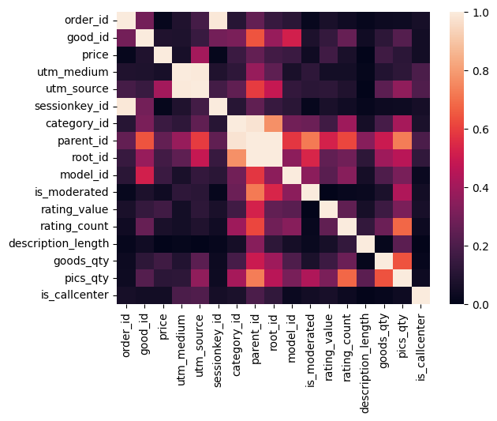

```python
interval_cols_for_phik = [
    'price',
    'rating_value',
    'rating_count',
    'description_length',
    'goods_qty',
    'pics_qty'
    'order_id',
    'good_id',
    'sessionkey_id',
    'category_id',
    'model_id',
    'order_id',
]

corr = smart_corr(data.drop(['create_time', 'model_create_time'], axis=1),
                   hue='is_callcenter', interval_cols=interval_cols_for_phik, head=100, hm=True)
```

```python
corr
```

|  | is_callcenter |
| --- | --- |
| is_callcenter | 1.000000 |
| utm_source | 0.209766 |
| parent_id | 0.198603 |
| utm_medium | 0.198541 |
| root_id | 0.131919 |
| category_id | 0.070818 |
| rating_value | 0.064093 |
| order_id | 0.058797 |
| sessionkey_id | 0.057022 |
| price | 0.048400 |
| good_id | 0.047935 |
| is_moderated | 0.047315 |
| pics_qty | 0.038851 |
| rating_count | 0.031878 |
| model_id | 0.031041 |
| goods_qty | 0.016296 |
| description_length | 0.006994 |

Как видно, у нас полно буквально мусорных признаков для предсказания (как мне кажется). Кроме того, прослеживается явная связь `order_id` и `sessionkey_id`, хоть она не идеальная (даже из количества уникальных значений). Давайте как раз изучим как ведёт себя таблица `t1_webstat`

```python
webstat.head(7)
```

|  | sessionkey_id | date_time | page_type | pageview_number | pageview_duration_sec | category_id | model_id | good_id | price | product_in_sale |
| --- | --- | --- | --- | --- | --- | --- | --- | --- | --- | --- |
| 0 | 122243978 | 1975-12-18 14:52:38.130 | 2 | 28 | 53.0 | 1773.0 | NaN | NaN | NaN | NaN |
| 1 | 122243978 | 1975-12-18 15:02:32.403 | 5 | 36 | 163.0 | NaN | NaN | NaN | NaN | NaN |
| 2 | 122243978 | 1975-12-18 15:08:11.147 | 5 | 40 | 156.0 | NaN | NaN | NaN | NaN | NaN |
| 3 | 122243992 | 1975-12-18 14:23:33.177 | 1 | 4 | 565.0 | 3973.0 | 26706175.0 | 45171119.0 | 8436.0 | 1.0 |
| 4 | 122243992 | 1975-12-18 14:32:58.763 | 1 | 5 | 73.0 | 3973.0 | 17297250.0 | 65195750.0 | 6624.0 | 1.0 |
| 5 | 122243998 | 1975-12-18 14:21:46.550 | 1 | 2 | 15.0 | 1870.0 | 268894.0 | 59718865.0 | 691.0 | 1.0 |
| 6 | 122244115 | 1975-12-18 14:20:53.793 | 7 | 1 | 62.0 | NaN | NaN | NaN | NaN | NaN |

```python
webstat.info()
```

```
<class 'pandas.core.frame.DataFrame'>
RangeIndex: 3334243 entries, 0 to 3334242
Data columns (total 10 columns):
 #   Column                 Dtype
---  ------                 -----
 0   sessionkey_id          int64
 1   date_time              object
 2   page_type              int64
 3   pageview_number        int64
 4   pageview_duration_sec  float64
 5   category_id            float64
 6   model_id               float64
 7   good_id                float64
 8   price                  float64
 9   product_in_sale        float64
dtypes: float64(6), int64(3), object(1)
memory usage: 254.4+ MB
```

```python
get_df_info(webstat)
```

|  | dtype | vc_max_el | vc_max_freq | nunique | nan | zero | empty_str | trash_score |
| --- | --- | --- | --- | --- | --- | --- | --- | --- |
| product_in_sale | float64 | 1.0 | 1.000 | 2 | 0.633 | -1 | -1 | 1.0 |
| good_id | float64 | 66921494.0 | 0.001 | 233144 | 0.633 | -1 | -1 | 0.633 |
| price | float64 | 952.0 | 0.004 | 12299 | 0.633 | -1 | -1 | 0.633 |
| model_id | float64 | 18340251.0 | 0.002 | 181760 | 0.613 | -1 | -1 | 0.613 |
| category_id | float64 | 155.0 | 0.054 | 3549 | 0.294 | -1 | -1 | 0.294 |
| pageview_duration_sec | float64 | 9.0 | 0.025 | 2975 | 0.088 | 0.006 | -1 | 0.094 |
| sessionkey_id | int64 | 0.0 | 0.000 | 328430 | -1 | -1 | -1 | -1 |
| date_time | object | 1976-01-25 22:35:55.557 | 0.000 | 3329535 | -1 | -1 | -1 | -1 |
| page_type | int64 | 1 | 0.387 | 13 | -1 | -1 | -1 | -1 |
| pageview_number | int64 | 1 | 0.097 | 632 | -1 | -1 | -1 | -1 |

Грустно, что в этой таблице нет уникальных ключей. Даже время не имеет столько же уникальных узначей, что и количество колонок.  
Как можно увидеть, у нас есть одинаковая доля nan'ов (по крайней мере до 3го знака после запятой) в трёх колонках: `product_in_sale`, `good_id`, `price`, я предполагаю, что они стоят все в одном месте, что надо проверить и в случае чего заменить их значение

```python
# Да, действительно все пропущенные значения в этих колонках совпадают по строчкам
print(np.all(webstat['product_in_sale'].isna() == webstat['price'].isna()))
print(np.all(webstat['product_in_sale'].isna() == webstat['good_id'].isna()))

webstat['product_in_sale'] = webstat['product_in_sale'].fillna(0).astype('int32')
webstat['price'] = webstat['price'].fillna(0).astype('int32')
webstat['good_id'] = webstat['good_id'].fillna(0).astype('int32')
```

```
True
True
```

Теперь давайте подумаем, может ли нам вообще пригодиться эта таблица `webstat`, если мы заходим соединить её по ключу `sessionkey_id`. Чтобы не делать бесполезную работу, давайте посмотрим есть ли такие `sessionkey_id` в тесте. Предполагаю, что нет, и нам придётся соединять данные по `good_id`

```python
# Как можно увидеть, у нас всего несколько значений совпадают, чего будет очень мало.
# Логически это нормально, что id (практически) не совпадают в тесте и трейне
print_diff_between_sets(data, test, 'sessionkey_id', 'train', 'test')
print('##################')
# А тут уже интереснее, и стала понятнее природа таблицы t1_webstat
print_diff_between_sets(webstat, test, 'sessionkey_id', 'webstat', 'test')
print('##################')
print_diff_between_sets(webstat, data, 'sessionkey_id', 'webstat', 'train')
```

```
Количество уникальных sessionkey_id в train: 96803
Количество уникальных sessionkey_id в test: 16019
Количество совпадающих sessionkey_id: 13
Количество уникальных sessionkey_id в test, которых нет в train: 16006
##################
Количество уникальных sessionkey_id в webstat: 328430
Количество уникальных sessionkey_id в test: 16019
Количество совпадающих sessionkey_id: 15880
Количество уникальных sessionkey_id в test, которых нет в webstat: 139
##################
Количество уникальных sessionkey_id в webstat: 328430
Количество уникальных sessionkey_id в train: 96803
Количество совпадающих sessionkey_id: 96277
Количество уникальных sessionkey_id в train, которых нет в webstat: 526
```

```python
print_diff_between_sets(data, test, 'good_id', 'train', 'test')
print('##################')
print_diff_between_sets(webstat, test, 'good_id', 'webstat', 'test')
print('##################')
print_diff_between_sets(webstat, data, 'good_id', 'webstat', 'train')
```

```
Количество уникальных good_id в train: 53691
Количество уникальных good_id в test: 12183
Количество совпадающих good_id: 4743
Количество уникальных good_id в test, которых нет в train: 7440
##################
Количество уникальных good_id в webstat: 233144
Количество уникальных good_id в test: 12183
Количество совпадающих good_id: 10537
Количество уникальных good_id в test, которых нет в webstat: 1646
##################
Количество уникальных good_id в webstat: 233144
Количество уникальных good_id в train: 53691
Количество совпадающих good_id: 48142
Количество уникальных good_id в train, которых нет в webstat: 5549
```

Из этих пересечений мы узнали много нового. Первый из инсайдов в том, что если мы заходим использовать `good_id` (id товара) в качестве признака для предсказания, то данных из `train` нам будет недостаточно, т.к. в `test` содержатся товары, которых нет в `train`  
Второй инсайд -- это знание, количество уникальных товаров в `webstat` много больше чем в `train`, даже учитывая, что в `webstat` подавляющее количество nan'ов. Значит, что простой join webstat к data может создать много проблем и расплодить табличку.  
Пока нет идей, как граммотно прибавить информацию из `webstat`, чтобы получить больше информации. Тут могут помочь только различные эксперименты. Есть идея только как-то агрегировать информацию сколько сессий было на один `order_id`

```python
# Перед тем, как начать работать с библиотеками, давайте предобработаем время
data['create_time'] = pd.to_datetime(data['create_time'])
data['model_create_time'] = pd.to_datetime(data['model_create_time'])

# Для использования catboost, я решил, что оставлю колонки со временем, просто буду дропать их для работы с другими моделями
# data['year_create_time'] = data['create_time'].dt.year
# data['month_create_time'] = data['create_time'].dt.month
# data['day_create_time'] = data['create_time'].dt.day
# data['hour_create_time'] = data['create_time'].dt.hour

# data['year_model_create_time'] = data['model_create_time'].dt.year
# data['month_model_create_time'] = data['model_create_time'].dt.month
# data['day_model_create_time'] = data['model_create_time'].dt.day
# data['hour_model_create_time'] = data['model_create_time'].dt.year

# Заодно давайте удалим ненужные по моему мнению колонки
#data = data.drop(['create_time', 'model_create_time'], axis=1)
```

```python
data.head(3)
```

|  | order_id | create_time | good_id | price | utm_medium | utm_source | sessionkey_id | category_id | parent_id | root_id | model_id | is_moderated | rating_value | rating_count | description_length | goods_qty | pics_qty | model_create_time | is_callcenter |
| --- | --- | --- | --- | --- | --- | --- | --- | --- | --- | --- | --- | --- | --- | --- | --- | --- | --- | --- | --- |
| 0 | 1269921 | 1975-12-26 09:30:08 | 9896348 | 753 | 5 | 8 | 123777004 | 139 | 133 | 124 | 123517 | 1 | 5.0 | 6.0 | 1204 | 6 | 2 | 1971-04-14 00:15:20 | 1 |
| 1 | 1270034 | 1975-12-26 10:28:57 | 9896348 | 753 | 1 | 2 | 123781654 | 139 | 133 | 124 | 123517 | 1 | 5.0 | 6.0 | 1204 | 6 | 2 | 1971-04-14 00:15:20 | 0 |
| 2 | 1268272 | 1975-12-25 11:24:28 | 9896348 | 753 | 2 | 3 | 123591002 | 139 | 133 | 124 | 123517 | 1 | 5.0 | 6.0 | 1204 | 6 | 2 | 1971-04-14 00:15:20 | 1 |

# Brute использование LightGMB

Тут я хочу посмотреть на бейслайн предсказания рандома и библиотек, если я не буду никак дополнительно обрабатывать данные (кроме минорных изменений, что я сделал выше). Это нужно, чтобы приблизительно понимать делаю ли я полезные вещи, или страдаю фигнёй.

```python
X_train, X_val, y_train, y_val = train_test_split(data.drop(['is_callcenter',
                                                             'order_id',
                                                             #'sessionkey_id',
                                                             'model_id',
                                                             'create_time', 'model_create_time'], axis=1),
                                                  data['is_callcenter'],
                                                  test_size=0.33,
                                                  random_state=42)
```

```python
# в качестве вероятности позвонить в колл-центр я из единицы вычел долю нулей в train
p = 1 - 0.645
y_random_pred = stats.binom.rvs(1, p, size=len(y_val), random_state=42)
print(roc_auc_score(y_val, y_random_pred))
```

```
0.5006503430750981
```

```python
# Теперь используем brute подход к LightGBM
lgb_tr = lgb.Dataset(X_train, label=y_train, free_raw_data=False)
lgb_val = lgb.Dataset(X_val, label=y_val, free_raw_data=False)

params = {
    'objective': 'binary', # or custom callable
    'eta': 0.3,
    'lambda': 1e-3,
    'metric': ['auc', ''],
    'seed': 42,
    'num_threads': 32,
    'verbosity': 1
}

model = lgb.train(
    params, lgb_tr, num_boost_round=50, # basic
    valid_sets=[lgb_val], valid_names=['валидация'],
    callbacks=[
        lgb.early_stopping(stopping_rounds=3, min_delta=0.),
        lgb.log_evaluation(period=5) # чтобы выводились результаты подсчета метрики для early_stopping
   ]
)
```

```
[LightGBM] [Info] Number of positive: 24853, number of negative: 45225
[LightGBM] [Info] Auto-choosing col-wise multi-threading, the overhead of testing was 0.007004 seconds.
You can set `force_col_wise=true` to remove the overhead.
[LightGBM] [Info] Total Bins 1821
[LightGBM] [Info] Number of data points in the train set: 70078, number of used features: 14
[LightGBM] [Info] [binary:BoostFromScore]: pavg=0.354648 -> initscore=-0.598672
[LightGBM] [Info] Start training from score -0.598672
Training until validation scores don't improve for 3 rounds
[5]	валидация's auc: 0.634174
[10]	валидация's auc: 0.639714
[15]	валидация's auc: 0.642308
[20]	валидация's auc: 0.642877
Early stopping, best iteration is:
[19]	валидация's auc: 0.643364
```

```python
y_lgb1_pred = model.predict(X_val)
print(roc_auc_score(y_val, y_lgb1_pred))
```

```
0.6433644630926836
```

Как можно увидеть, прямое использование `lgb` не даёт больших результатов, только 15 процентных пункта к результату рандомного угадывания

# Эксперименты с присоединением информации из `webstat` в `train`

```python
# Для начала давайте подсчитаем количество сессий на каждый order_id
sessions_count = webstat['sessionkey_id'].value_counts().reset_index()
sessions_count.columns = ['sessionkey_id', 'sessions_per_order']

data = pd.merge(data, sessions_count, on='sessionkey_id', how='left')
data['sessions_per_order'] = data['sessions_per_order'].fillna(0).astype('int32')
```

```python
# Кроме того, хочу агрегировать признак pageview_duration_sec, который как мне кажется интересным
session_durations = webstat.groupby('sessionkey_id')['pageview_duration_sec'].sum().reset_index()
session_durations.columns = ['sessionkey_id', 'total_duration_per_session']

data = pd.merge(data, session_durations, on='sessionkey_id', how='left')
data['total_duration_per_session'] = data['total_duration_per_session'].fillna(0).astype('int32')
```

```python
# Соответственно можно добавить среднее время на страницах
mean_session_durations = webstat.groupby('sessionkey_id')['pageview_duration_sec'].mean().reset_index()
mean_session_durations.columns = ['sessionkey_id', 'mean_duration_per_session']

data = pd.merge(data, mean_session_durations, on='sessionkey_id', how='left')
data['mean_duration_per_session'] = data['mean_duration_per_session'].fillna(0).astype('int32')
```

```python
# Может быть мне поможет информация о том, какие строчки в webstat не имели наны в последних трёх колонках
nans_field = webstat.groupby('sessionkey_id')['product_in_sale'].sum().reset_index()
nans_field.columns = ['sessionkey_id', 'nans_field']

data = pd.merge(data, nans_field, on='sessionkey_id', how='left')
data['nans_field'] = data['nans_field'].fillna(0).astype('int32')
```

```python
# Соответственно добавим и среднее число не нанов в таблице
mean_nans = data.nans_field / (data.sessions_per_order +1)
data['mean_nans'] = mean_nans
```

Давайте теперь попробуем наоборот присоединить к таблице `webstat` значения `is_callcenter`

```python
new_view_webstat = pd.merge(webstat, data[['sessionkey_id', 'is_callcenter']], on='sessionkey_id', how='left')
new_view_webstat['is_callcenter'].fillna(-1, inplace=True)
```

```python
new_view_webstat_sample = new_view_webstat.sample(5000)
feature_distributions(new_view_webstat_sample[new_view_webstat_sample['is_callcenter'] != -1], 'is_callcenter')
```

```python
page_sample = webstat.groupby('sessionkey_id')['page_type'].sample().reset_index()
nans_field.columns = ['sessionkey_id', 'page_sample']

data = pd.merge(data, nans_field, on='sessionkey_id', how='left')
data['page_sample'] = data['page_sample'].fillna(0).astype('int32')
```

Остальные признаки мне не кажутся интересными

```python
data.head()
```

|  | order_id | create_time | good_id | price | utm_medium | utm_source | sessionkey_id | category_id | parent_id | root_id | ... | goods_qty | pics_qty | model_create_time | is_callcenter | sessions_per_order | total_duration_per_session | mean_duration_per_session | nans_field | mean_nans | page_sample |
| --- | --- | --- | --- | --- | --- | --- | --- | --- | --- | --- | --- | --- | --- | --- | --- | --- | --- | --- | --- | --- | --- |
| 0 | 1269921 | 1975-12-26 09:30:08 | 9896348 | 753 | 5 | 8 | 123777004 | 139 | 133 | 124 | ... | 6 | 2 | 1971-04-14 00:15:20 | 1 | 1 | 0 | 0 | 1 | 0.500000 | 1 |
| 1 | 1270034 | 1975-12-26 10:28:57 | 9896348 | 753 | 1 | 2 | 123781654 | 139 | 133 | 124 | ... | 6 | 2 | 1971-04-14 00:15:20 | 0 | 28 | 3831 | 141 | 12 | 0.413793 | 12 |
| 2 | 1268272 | 1975-12-25 11:24:28 | 9896348 | 753 | 2 | 3 | 123591002 | 139 | 133 | 124 | ... | 6 | 2 | 1971-04-14 00:15:20 | 1 | 7 | 370 | 61 | 2 | 0.250000 | 2 |
| 3 | 1270544 | 1975-12-26 14:16:06 | 9896348 | 753 | 1 | 1 | 123832302 | 139 | 133 | 124 | ... | 6 | 2 | 1971-04-14 00:15:20 | 1 | 6 | 1926 | 385 | 0 | 0.000000 | 0 |
| 4 | 1270970 | 1975-12-26 18:21:47 | 9896348 | 753 | 3 | 56 | 123881603 | 139 | 133 | 124 | ... | 6 | 2 | 1971-04-14 00:15:20 | 0 | 6 | 94 | 15 | 1 | 0.142857 | 1 |

5 rows × 25 columns

# Собираем всю предобработку

Блок ниже будет ещё дополняться

```python
def preprocess(data, webstat, web_flag=False):
    data['utm_source'] = data['utm_source'].fillna(-1)
    data['utm_source'] = data['utm_source'].astype('int32')
    webstat['product_in_sale'] = webstat['product_in_sale'].fillna(0).astype('int32')
    webstat['price'] = webstat['price'].fillna(0).astype('float')
    webstat['good_id'] = webstat['good_id'].fillna(0).astype('int32')

    data['create_time'] = pd.to_datetime(data['create_time'])
    data['model_create_time'] = pd.to_datetime(data['model_create_time'])
    webstat['date_time'] = pd.to_datetime(webstat['date_time'])

    # Для начала давайте подсчитаем количество сессий на каждый order_id
    sessions_count = webstat['sessionkey_id'].value_counts().reset_index()
    sessions_count.columns = ['sessionkey_id', 'sessions_per_order']
    data = pd.merge(data, sessions_count, on='sessionkey_id', how='left')
    data['sessions_per_order'] = data['sessions_per_order'].fillna(0).astype('int32')

    # Кроме того, хочу агрегировать признак pageview_duration_sec, который как мне кажется интересным
    session_durations = webstat.groupby('sessionkey_id')['pageview_duration_sec'].sum().reset_index()
    session_durations.columns = ['sessionkey_id', 'total_duration_per_session']
    data = pd.merge(data, session_durations, on='sessionkey_id', how='left')
    data['total_duration_per_session'] = data['total_duration_per_session'].fillna(0).astype('int32')

    # Кроме суммы давайте попробуем агрегировать pageview_duration_sec как среднее
    mean_session_durations = webstat.groupby('sessionkey_id')['pageview_duration_sec'].mean().reset_index()
    mean_session_durations.columns = ['sessionkey_id', 'mean_duration_per_session']
    data = pd.merge(data, mean_session_durations, on='sessionkey_id', how='left')
    data['mean_duration_per_session'] = data['mean_duration_per_session'].fillna(0).astype('int32')

    # Как узнали ранее давайте запишем в data знание о том, сколько было не пропущенных значений в последних трёх колонках webstat
    nans_field = webstat.groupby('sessionkey_id')['product_in_sale'].sum().reset_index()
    nans_field.columns = ['sessionkey_id', 'nans_field']
    data = pd.merge(data, nans_field, on='sessionkey_id', how='left')
    data['nans_field'] = data['nans_field'].fillna(0).astype('int32')

    # так же попробуем воспользоваться знанием о среднем количестве не нанов на один order_id
    mean_nans = data.nans_field / (data.sessions_per_order + 1)
    data['mean_nans'] = mean_nans

    # агрегация информации о page_type. Давайте попробуем вставить самое часто встречаемое значение
    page_type_counts = webstat.groupby(['sessionkey_id', 'page_type']).size().reset_index(name='counts')
    page_type_counts_sorted = page_type_counts.sort_values(by=['sessionkey_id', 'counts'], ascending=[True, False])
    most_frequent_page_type = page_type_counts_sorted.drop_duplicates(subset=['sessionkey_id'])
    data = pd.merge(data, most_frequent_page_type[['sessionkey_id', 'page_type']], on='sessionkey_id', how='left')
    data['page_type'] = data['page_type'].fillna(-1).astype('int32')

    # Попробуем исследовать разность дат между таблицами train И webstat
    arg_date_web = webstat.groupby('sessionkey_id')['date_time'].mean().reset_index()
    tmp_time = pd.merge(data[['order_id', 'create_time', 'sessionkey_id']], arg_date_web, on='sessionkey_id', how='left')
    tmp_time['diff_time'] = tmp_time['date_time'] - tmp_time['create_time']
    data = pd.merge(data, tmp_time[['sessionkey_id', 'diff_time']], on='sessionkey_id', how='left')
    data['diff_time'] = data['diff_time'].fillna(pd.to_timedelta(0)).dt.days

    data['root_id'] = data['root_id'].clip(upper=2500)

    data['rating_value'] = data['rating_value'].fillna(-1).astype('int32')
    data['rating_count'] = data['rating_count'].fillna(-1).astype('int32')

    data = data.drop(['good_id',
                      'category_id',
                      'model_id',
                      'model_create_time',
                      'description_length',
                      'goods_qty',], axis=1)

    if web_flag:
        return data.copy(), webstat.copy()
    return data.copy()
```

```python
data = pd.read_csv('train.csv', sep=',')
test = pd.read_csv('test.csv', sep=',')
webstat = pd.read_csv('t1_webstat.csv', sep=',')

data = preprocess(data, webstat)
test = preprocess(test, webstat)
data.to_csv('preprocess_train.csv', sep=',', index=False)
test.to_csv('preprocess_test.csv', sep=',', index=False)
```

```python
data.head(3)
```

[output not shown]

# Меняем планы

Я уже потратил 16 часов на обработку данных. Максимальный результат, который я получал - это 0.84 на валидационной выборке. Мне это надоело, этого мало, надо менять тактику. До этого я агрегировал значения в `webstat` и джоинил их `train`, теперь я буду джоинить значения из `train` в `webstat` по `sessionkey_id`. Да, у нас есть `sessionkey_id` в `train` и `test`, которых нет в `webstat`, но с этим мы разберёмся позже. Сейчас нужно написать метод, чтобы валидироваться.

```python
data = pd.read_csv('train.csv', sep=',')
test = pd.read_csv('test.csv', sep=',')
webstat = pd.read_csv('t1_webstat.csv', sep=',')
```

Как было замечено ранее, в `train` у нас есть неуникальные `sessionkey_id`. Для начала давайте проверим, есть ли у нас одинаковые `sessionkey_id` с разными значениями `is_callcanter`

```python
duplic_ses_id = data[data.duplicated('sessionkey_id', keep=False)]
print(duplic_ses_id.shape)
duplic_ses_id.groupby('sessionkey_id')['is_callcenter'].transform(lambda x: x.nunique() > 1).sum()
```

```
(14193, 19)
```

```
1487
```

Тут мы увидели, ужасную вещь! Для некоторых `sessionkey_id` у нас есть разные предсказания. И таких предсказаний у нас целый процент... Неприятно, но деваться некуда :(

Теперь давайте подумаем, как правильно проводить валидацию. Для начала мы разобьём `data` на трейн и валидацию. Заджоиним трейн к `webstat`, после чего будет тренировать модель на тех строчках, где есть предсказание.

```python
X_train, X_val, y_train, y_val = train_test_split(data.drop(['is_callcenter'], axis=1),
                                                  data['is_callcenter'],
                                                  test_size=0.33,
                                                  random_state=42)
data_train = X_train.assign(is_callcenter = y_train)
data_val = X_val.assign(is_callcenter = y_val)
```

```python
web_train = pd.merge(webstat, data_train[['order_id', 'sessionkey_id', 'is_callcenter']], on='sessionkey_id', how='left')
web_train = web_train[web_train['is_callcenter'].notna()]

web_val = pd.merge(webstat, data_val[['order_id', 'sessionkey_id', 'is_callcenter']], on='sessionkey_id', how='left')
web_val = web_val[web_val['is_callcenter'].notna()]
```

```python
def web_proc(web):
    web['product_in_sale'] = web['product_in_sale'].fillna(0).astype('int32')
    web['price'] = web['price'].fillna(0).astype('float')
    web['good_id'] = web['good_id'].fillna(0).astype('int32')

    web['date_time'] = pd.to_datetime(web['date_time'])
    web = web.drop(['date_time'], axis=1)
    return web.copy()

web_train = web_proc(web_train)
web_val = web_proc(web_val)
```

```python
def lgb_model_train(web_train, web_val):
    lgb_tr = lgb.Dataset(web_train.drop(['is_callcenter'], axis=1),
                        label=web_train['is_callcenter'], free_raw_data=False)
    lgb_val = lgb.Dataset(web_val.drop('is_callcenter', axis=1),
                        label=web_val['is_callcenter'], free_raw_data=False)

    params = {
        'objective': 'binary',
        'eta': 0.05,
        'max_leaves': 2**9,
        'metric': ['auc', ''],
        'seed': 42,
        'num_threads': 32,
        'verbosity': 0,
        'is_unbalance': True
    }

    model = lgb.train(
        params, lgb_tr, num_boost_round=100, # basic
        valid_sets=[lgb_val], valid_names=['предварительная валидация'],
        callbacks=[
            lgb.early_stopping(stopping_rounds=10, min_delta=0.),
            lgb.log_evaluation(period=10) # чтобы выводились результаты подсчета метрики для early_stopping
    ]
    )

    return model
```

```python
model = lgb_model_train(web_train, web_val)
```

[output not shown]

Теперь тут посчитаем какой скор на самом деле

```python
def lgb_model_predict(model, X_val, y_val, web_val):
   p = 1 - 0.645
   counter = 0
   y_pred = []
   for id in X_val.order_id:
      pred_id = X_val[X_val['order_id'] == id]['sessionkey_id'].to_numpy()[0]
      tmp = web_val[web_val['sessionkey_id'] == pred_id].drop('is_callcenter', axis=1)
      if tmp.shape[0] != 0:
         y_pred_all = model.predict(tmp)
      else:
         counter+=1
         y_pred_all = stats.binom.rvs(1, p, size=5)
      y_pred.append(y_pred_all.mean())
   print(roc_auc_score(y_val, y_pred))
   print(f'Случайных предсказаний было {counter/len(y_val)}')

   return y_pred
```

```python
y_pred = lgb_model_predict(model, X_val, y_val, web_val)
```

[output not shown]

Подзравляем, мы научились валидироваться. Вот такой скор мы получаем на самом деле. Это даже обидно, что без предобработки, можно получить такие высоты. С `train` мне понадобилось очень много времени для этого. Но это полезный опыт: `иногда полезней будет агрегировать не данные, а ответы`

Так давайте же попробуем добавить обработку и посмотрим, что получится.

# Тут начинается Новая обработка

```python
def web_proc(web, data, cat_cols):
    # Заполняем пропуски
    web['product_in_sale'] = web['product_in_sale'].fillna(0).astype('int32')
    web['price'] = web['price'].fillna(0).astype('float')
    web['good_id'] = web['good_id'].fillna(0).astype('int32')

    # Считаем количество одинаковых сессий
    tmp = web['sessionkey_id'].value_counts().reset_index()
    tmp.columns = ['sessionkey_id', 'sessions_per_order']
    web = pd.merge(web, tmp, on='sessionkey_id', how='left')
    web['sessions_per_order'] = web['sessions_per_order'].fillna(-1).astype('int32')

    # Кроме того, хочу агрегировать признак pageview_duration_sec, который как мне кажется интересным
    web['pageview_duration_sec'] = web['pageview_duration_sec'].clip(lower=0, upper=200)
    session_durations = web.groupby('sessionkey_id')['pageview_duration_sec'].sum().reset_index()
    session_durations.columns = ['sessionkey_id', 'total_duration_per_session']
    web = pd.merge(web, session_durations, on='sessionkey_id', how='left')
    web['total_duration_per_session'] = web['total_duration_per_session'].fillna(0).astype('int32')

    # Кроме суммы давайте попробуем агрегировать pageview_duration_sec как среднее
    mean_session_durations = web.groupby('sessionkey_id')['pageview_duration_sec'].mean().reset_index()
    mean_session_durations.columns = ['sessionkey_id', 'mean_duration_per_session']
    web = pd.merge(web, mean_session_durations, on='sessionkey_id', how='left')
    web['mean_duration_per_session'] = web['mean_duration_per_session'].fillna(0).astype('int32')

    # Как узнали ранее давайте запишем в web знание о том, сколько было не пропущенных значений в последних трёх колонках webstat
    nans_field = webstat.groupby('sessionkey_id')['product_in_sale'].sum().reset_index()
    nans_field.columns = ['sessionkey_id', 'nans_field']
    web = pd.merge(web, nans_field, on='sessionkey_id', how='left')
    web['nans_field'] = web['nans_field'].fillna(0).astype('int32')

    web['mean_nans'] = web.nans_field / (web.sessions_per_order + 1)

    # Давайте сравним время из таблицы train
    data_time = data[['sessionkey_id', 'create_time']]
    data_time['create_time'] = pd.to_datetime(data_time['create_time'])
    web['date_time'] = pd.to_datetime(web['date_time'])
    web = pd.merge(web, data_time, on='sessionkey_id', how='left')
    web['diff_time'] = web['date_time'] - web['create_time']
    web['diff_time'] = web['diff_time'].fillna(pd.to_timedelta(0)).dt.days

    # Заполним пропущенные значения в category_id. Тут горлышко по быстродействию из-за лямбда функции
    most_frequent = web.groupby('sessionkey_id')['category_id'].transform(lambda x: x.mode().iloc[0] if not x.mode().empty else -1)
    web['category_id'] = web['category_id'].fillna(most_frequent)

    # Кроме того колонка is_moderated и parent_id как показало исследование неплохо себя
    web = pd.merge(web, data[['sessionkey_id', 'is_moderated']], on='sessionkey_id', how='left')
    web = pd.merge(web, data[['sessionkey_id', 'parent_id']], on='sessionkey_id', how='left')

    for col in cat_cols:
        web[col] = web[col].astype('category')

    web = web.drop(['date_time', 'create_time', 'model_id', 'price'], axis=1)

    return web.copy()
```

Теперь мы будем делить `webstat` на тестовую и валидационную выборку, потому что таблица `webstat` всё равно нам всегда известна. Поэтому её обработка будет в одном цикле. Ещё нам нужно обновить то, как мы обучает и предсказываем (особенно предсказываем)

```python
cat_cols = ['page_type', 'category_id', 'good_id', 'product_in_sale', 'is_moderated', 'parent_id']
```

```python
X_train, X_val, y_train, y_val = train_test_split(data.drop(['is_callcenter'], axis=1),
                                                  data['is_callcenter'],
                                                  test_size=0.33,
                                                  random_state=42)

web = pd.merge(webstat, data[['sessionkey_id', 'is_callcenter']], on='sessionkey_id', how='left')
web = web_proc(web, data, cat_cols)
```

```python
# Чуть обновим трейн, добавив категориальные колонки
def lgb_model_train(X_train, X_val, web, cat_cols):

    web_train = web[web['sessionkey_id'].isin(X_train['sessionkey_id'])]
    web_val = web[web['sessionkey_id'].isin(X_val['sessionkey_id'])]

    lgb_tr = lgb.Dataset(web_train.drop(['is_callcenter'], axis=1),
                        label=web_train['is_callcenter'], categorical_feature=cat_cols, free_raw_data=False)
    lgb_val = lgb.Dataset(web_val.drop('is_callcenter', axis=1),
                        label=web_val['is_callcenter'], categorical_feature=cat_cols, free_raw_data=False)

    params = {
        'objective': 'binary',
        'eta': 0.1,
        'max_leaves': 2**8,
        'metric': ['auc', ''],
        'seed': 42,
        'num_threads': 32,
        'verbosity': 0,
        'is_unbalance': True
    }

    model = lgb.train(
        params, lgb_tr, num_boost_round=50, # basic
        valid_sets=[lgb_val], valid_names=['предварительная валидация'],
        callbacks=[
            lgb.early_stopping(stopping_rounds=5, min_delta=0.),
            lgb.log_evaluation(period=10) # чтобы выводились результаты подсчета метрики для early_stopping
    ]
    )

    return model
```

```python
# И очень важно обновить предикт, ведь его обработка занимает более получаса
def lgb_model_predict(model, X_val, web):
   y_pred = []
   p = 1 - 0.645
   counter = 0
   web_val = web[web['sessionkey_id'].isin(X_val['sessionkey_id'])]
   web_val['y_prob'] = model.predict(web_val.drop('is_callcenter', axis=1))
   print('Закончил предикт')

   for id in X_val.order_id:
      ses = X_val[X_val['order_id']==id]['sessionkey_id']
      tmp = web_val[web_val['sessionkey_id'].isin(ses)]
      if tmp.shape[0] != 0:
         if tmp[tmp['is_callcenter'].notna()]['is_callcenter'].shape[0] != 0:
               y_pred_all = tmp[tmp['is_callcenter'].notna()]['is_callcenter']
         else:
               y_pred_all = tmp[tmp['y_prob'].notna()]['y_prob']
      else:
         counter+=1
         y_pred_all = stats.binom.rvs(1, p, size=5)
      y_pred.append(y_pred_all.mean())

   print(f'Случайных предсказаний было {counter/X_val.shape[0]}')

   return y_pred
```

```python
# Сделаем вторую версию для предикта, чтобы посмотреть, что быстрее
def lgb_model_predict_2(model, X_val, web):
    y_pred = []
    p = 1 - 0.645
    counter = 0
    web_val = web[web['sessionkey_id'].isin(X_val['sessionkey_id'])]
    web_val['y_prob'] = model.predict(web_val.drop('is_callcenter', axis=1))
    print('Закончил предикт')

    merged_df = pd.merge(X_val[['order_id', 'sessionkey_id']], web_val, on='sessionkey_id', how='left')

    def compute_y_pred(group):
        if group['is_callcenter'].notna().any():
            y_pred_all = group['is_callcenter'].dropna()
        elif group['y_prob'].notna().any():
            y_pred_all = group['y_prob'].dropna()
        else:
            y_pred_all = pd.Series(stats.binom.rvs(1, p, size=5))
        return y_pred_all.mean()

    y_pred = merged_df.groupby('order_id').apply(compute_y_pred).tolist()
    print(counter)
    return y_pred
```

```python
model = lgb_model_train(X_train, X_val, web, cat_cols)
```

```
[LightGBM] [Warning] Categorical features with more bins than the configured maximum bin number found.
[LightGBM] [Warning] For categorical features, max_bin and max_bin_by_feature may be ignored with a large number of categories.
Training until validation scores don't improve for 5 rounds
[10]	предварительная валидация's auc: 0.782869
[20]	предварительная валидация's auc: 0.784135
[30]	предварительная валидация's auc: 0.78476
[40]	предварительная валидация's auc: 0.78506
[50]	предварительная валидация's auc: 0.785684
Did not meet early stopping. Best iteration is:
[50]	предварительная валидация's auc: 0.785684
```

```python
# 9 минут
y_pred = lgb_model_predict_2(model, X_val, web)
print(roc_auc_score(y_val, y_pred))
```

[output not shown]

```python
# 50 минут
y_pred = lgb_model_predict(model, X_val, web)
print(roc_auc_score(y_val, y_pred))
```

```
Закончил предикт
Случайных предсказаний было 0.005707332618709622
0.999386755796651
```

Я устал. Вроде векторизовал предикт, он работает быстрее, но выдаёт совершенно другой результат, нежели прошлая версия. Надоело ждать час, чтобы просто проверить предикт....